# Lab 06 - Ohm's Law Part 2 (Make-Up Lab Version)

Edit this cell and provide the information requested:

- Your name: Mary Hosseini
- Your student number: 41004235

```python
%reset -f
import numpy as np
import data_entry2
import matplotlib.pyplot as plt
```

## Part A - Intro & Learning Activities

### Notes From Slides

#### Reduced Chi-squared

1. Start with the residuals
2. Normalize residuals using uncertainty
3. Square the normalized residuals and add them together. We square them so that both positive and negative residuals all add up
4. Divide by the number of data points, N so that a set with more points isn't penalized/ We also want a model with more parameters to be penalized. P is the number of parameters in the model - for a straight line with only an adjustable slope, P=1. If a non-zero intercept is allowed, P=2.

#### Interpreting Reduced Chi-squared Value

- If = 1: The models fit the data well, assuming uncertainties have been characterized well
- If >> 1: Not a good fit or the uncertainties have been underestimated
- If << 1: The uncertainties have been overestimated
- Side Note: When using chi-squared, the goal is to adjust your fitting parameters in order to minimize the value for chi-squared, which indicates the best possible fit of your model to the data.
- Side Note #2: The goal is not to make chi-squared = 1, it is to minimize it to find the best possible fit, and then interpret the resulting chi-squared value.

#### A Good Fit After Minimization

- two-thirds of measurements within 1 deviation of the residuals zero-line
- Almost all (95%) within 2 deviations of the residuals zero line
- No trend in the data (data seems randomly scattered about the residuals zero line)

#### Experimental Goal

A comparison of the extent to which resistors and light bulbs obey Ohm's Law to determine the best fit slops to I vs V for a resistor and light bulb. In other words, we compare the degree to which these devices obey Ohm's Law.

### Notes from video

In this lab, we will use Chi-squared to determine the best-fitting procedure. In last week's lab, we were given the residuals, and we used the residuals as the parameters in our model to determine when we reached the best fit. However, the limitation of that method is that it still requires more interpretation. Using chi-squared we can determine how good our model fit is. We will keep repeating this until we reach the minimized chi-squared (the best fit to the data).

#### Tips

- Keep track of chi-squared value in a separate table to compare the different models' fits with different slopes
- Try to minimize chi-squared value as close to 1 as possible for the best fit
- Once you find the maximum and minimum best fit for slope value. Find the difference between the slope values and divide by 4 to get the uncertainty. Eg. if Max = 2.2 and Min = 2, uncertainty would be (2.2-2)/4=0.2/4=0.05 uncertainty

## Part B - Revisiting the fit to last week's data

```python
de = data_entry2.sheet_copy("../Lab05/lab05_lab2_ohms_law", "lab5data-copy")
```

```
Sheet name: lab5data-copy.csv
```

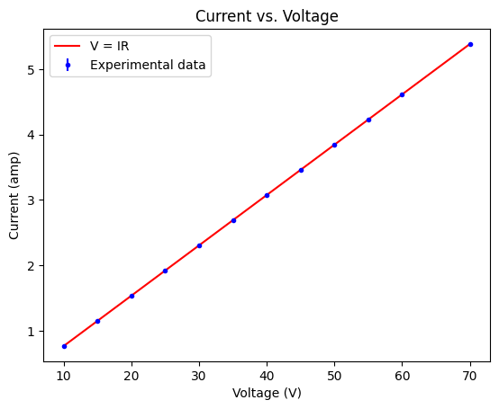

```
Weighted chi-squared:  1.008730674088043
```

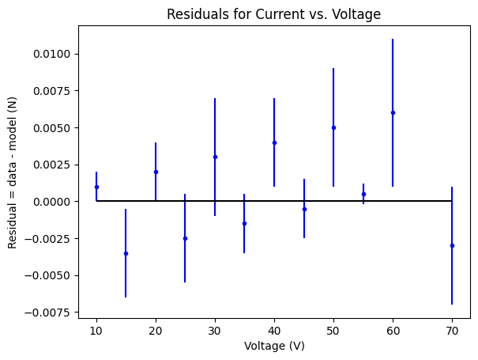

```python
# Scatter Plot
# 1: find the limits of the data:
xmin = np.min(VVec)
xmax = np.max(VVec)

# 2: generate a bunch of x points between xmin and xmax
xpoints = np.linspace(xmin, xmax, 100)

# 3: calculate the model values:
slope = 0.0769 # Our initial estimate of the slope
ypoints = xpoints * slope

# 4: plot the curve. We plot this as a red line "r-" :
plt.plot(xpoints, ypoints, "r-", label = "V = IR")

# 5: plot the data:
plt.errorbar(VVec, IVec, uIVec, fmt="bo", markersize = 3, label="Experimental data")
plt.title("Current vs. Voltage")
plt.xlabel("Voltage (V)")
plt.ylabel("Current (amp)")
plt.legend()
plt.show()

# Residuals plot
# Residuals step 1: Calculate the model at each x-datapoint
ymodel = slope * VVec # y = mx at each x_i

# Residuals step 2: Calcualte the residual vector
RVec = IVec - ymodel

# Calculate chi-squared
chi2 = np.sum((RVec/uIVec)**2)/(len(RVec)-1)
print("Weighted chi-squared: ", chi2)

# Resoduals step 3: Plot the residual vector against the x-data vector
plt.errorbar(VVec, RVec, uIVec, fmt="bo", markersize = 3)

# Residuals step 4: Add a R = 0 x-axis (horizontal line) to the plot
plt.hlines(y=0, xmin=xmin, xmax=xmax, color='k') # draw axis at y = 0.

# Residuals step 5: Add axis labels and title, and show the graph
plt.title("Residuals for Current vs. Voltage")
plt.xlabel("Voltage (V)")
plt.ylabel("Residual = data - model (N)")
plt.show()
```

```python
dec = data_entry2.sheet("chi2-1")
```

```
Sheet name: chi2-1.csv
```

```python
# Uncertainty
unc = (0.0770-0.0768) /4
unc
```

```
5.000000000000143e-05
```

#### What is your revised best estimate of the resistance of your resistor?

The previous estimate of the resistance in my resistor was 13.00Ω. Therefore, I did not change my revised best estimate of the resistance since the value is the same as 13.00Ω.a

#### What can you conclude about whether the model describes the data

Since the model slope is 0.0769 +/- 5.000e-05 N/m, I can conclude that the model accurately describes the data.

## Part C - Familiarize Part I (Build your circuit)

Built the circuit as instructed by lab instructions. Made sure to use the correct light bulb.

## Part D - Familiarize Part II (Explore)

#### What range of voltage should you use? Why did you choose this range?

I will use a similar range from 10 to 70 with 4 volt increases. I chose this range because from my previous measurements I learned that having a larger data set can help in calculating the most accurate results. It is important to mention that this is not always the case but I chose this range because when I did data measurement with a smaller range and a smaller data point value increases, I got very inaccurate results. Whereas when I perfomed calculations on a larger data set with greater data value increases, I got reasonable results with low uncertainty.

## Part E - Measure, Analyze, Reflect

```python
de2 = data_entry2.sheet("lab06_lab_ohms_law")
```

```
Sheet name: lab06_lab_ohms_law.csv
```

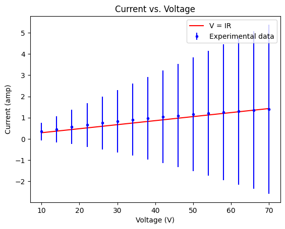

```
Weighted chi-squared:  0.035216899116065965
```

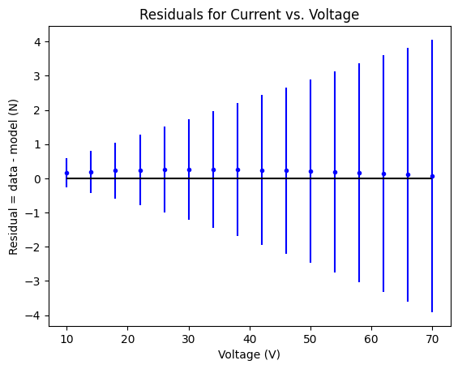

```python
# Scatter Plot
# 1: find the limits of the data:
xmin = np.min(VVec)
xmax = np.max(VVec)

# 2: generate a bunch of x points between xmin and xmax
xpoints = np.linspace(xmin, xmax, 100)

# 3: calculate the model values:
slope = 0.019 # Our initial estimate of the slope
ypoints = xpoints * slope +0.1

# 4: plot the curve. We plot this as a red line "r-" :
plt.plot(xpoints, ypoints, "r-", label = "V = IR")

# 5: plot the data:
plt.errorbar(VVec, IVec, uIVec, fmt="bo", markersize = 3, label="Experimental data")
plt.title("Current vs. Voltage")
plt.xlabel("Voltage (V)")
plt.ylabel("Current (amp)")
plt.legend()
plt.show()

# Residuals plot
# Residuals step 1: Calculate the model at each x-datapoint
ymodel = slope * VVec # y = mx at each x_i

# Residuals step 2: Calcualte the residual vector
RVec = IVec - ymodel

# Calculate chi-squared
chi2 = np.sum((RVec/uIVec)**2)/(len(RVec)-1)
print("Weighted chi-squared: ", chi2)

# Resoduals step 3: Plot the residual vector against the x-data vector
plt.errorbar(VVec, RVec, uIVec, fmt="bo", markersize = 3)

# Residuals step 4: Add a R = 0 x-axis (horizontal line) to the plot
plt.hlines(y=0, xmin=xmin, xmax=xmax, color='k') # draw axis at y = 0.

# Residuals step 5: Add axis labels and title, and show the graph
plt.title("Residuals for Current vs. Voltage")
plt.xlabel("Voltage (V)")
plt.ylabel("Residual = data - model (N)")
plt.show()
```

```python
# slope and u[slope]
slope_max = 0.021
slope_min = 0.017
slope_best = 0.019
u_slope = (slope_max-slope_min)/2
print("The model slope is with 68% confidence interval: {:.4f}+/-{:.4f} N/m".format(slope_best, u_slope))
# u[slope]/slope
uSlopebySlope = u_slope/slope_best
# R and u_R
R = 1/slope_best
u_R = R* (u_slope/slope)
# u[R]/R
uRbyR = u_R/R
print( "The calculated resistance of the resistor is: ", R)
print( "The calculated uncertainty of the resistor is: ", u_R)
```

```
The model slope is with 68% confidence interval: 0.0190+/-0.0020 N/m
The calculated resistance of the resistor is:  52.631578947368425
The calculated uncertainty of the resistor is:  5.54016620498615
```

## Part F - Iterate and Improve

#### Implemented Changes

I changed the range to 10 to 60. I also changed the values so that they increase by 5 volts.

```python
de2 = data_entry2.sheet("lab05_lab_ohms_law2")
```

```
Sheet name: lab05_lab_ohms_law2.csv
```

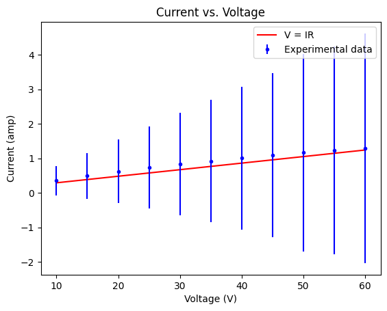

```
Weighted chi-squared:  0.04424704563954824
```

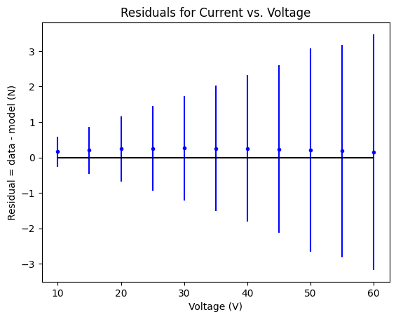

```python
# Scatter Plot
# 1: find the limits of the data:
xmin = np.min(VVec)
xmax = np.max(VVec)

# 2: generate a bunch of x points between xmin and xmax
xpoints = np.linspace(xmin, xmax, 100)

# 3: calculate the model values:
slope = 0.019 # Our initial estimate of the slope
ypoints = xpoints * slope + 0.1

# 4: plot the curve. We plot this as a red line "r-" :
plt.plot(xpoints, ypoints, "r-", label = "V = IR")

# 5: plot the data:
plt.errorbar(VVec, IVec, uIVec, fmt="bo", markersize = 3, label="Experimental data")
plt.title("Current vs. Voltage")
plt.xlabel("Voltage (V)")
plt.ylabel("Current (amp)")
plt.legend()
plt.show()

# Residuals plot
# Residuals step 1: Calculate the model at each x-datapoint
ymodel = slope * VVec # y = mx at each x_i

# Residuals step 2: Calcualte the residual vector
RVec = IVec - ymodel

# Calculate chi-squared
chi2 = np.sum((RVec/uIVec)**2)/(len(RVec)-1)
print("Weighted chi-squared: ", chi2)

# Resoduals step 3: Plot the residual vector against the x-data vector
plt.errorbar(VVec, RVec, uIVec, fmt="bo", markersize = 3)

# Residuals step 4: Add a R = 0 x-axis (horizontal line) to the plot
plt.hlines(y=0, xmin=xmin, xmax=xmax, color='k') # draw axis at y = 0.

# Residuals step 5: Add axis labels and title, and show the graph
plt.title("Residuals for Current vs. Voltage")
plt.xlabel("Voltage (V)")
plt.ylabel("Residual = data - model (N)")
plt.show()
```

```python
# slope and u[slope]
slope_max = 0.020
slope_min = 0.018
slope_best = 0.019
u_slope = (slope_max-slope_min)/2
print("The model slope is with 68% confidence interval: {:.4f}+/-{:.4f} N/m".format(slope_best, u_slope))
# u[slope]/slope
uSlopebySlope = u_slope/slope_best
# R and u_R
R = 1/slope_best
u_R = R* (u_slope/slope_best)
# u[R]/R
uRbyR = u_R/R
print( "The calculated resistance of the resistor is: ", R)
print( "The calculated uncertainty of the resistor is: ", u_R)
```

```
The model slope is with 68% confidence interval: 0.0190+/-0.0010 N/m
The calculated resistance of the resistor is:  52.631578947368425
The calculated uncertainty of the resistor is:  2.770083102493077
```

## Part G - Completing the Lab

### Summary of Results Lab 5

From the first and second rounds of results, I concluded that I was extremely confident that the experiment goal: resistor obeys Ohm's law. Using the collected results in round one of data collection, I concluded that the resistance was 12.99 Ω with an uncertainty of 0.05050 Ω. I also found the slope to be 0.07700 +/- 0.0003 N/m. Using improvement methods for data collection, from my second round of results I concluded that the resistance was 13.00 Ω with an uncertainty of 5.499e-05 Ω. I also found the slope to be 0.07690 +/- 0.0001000 N/m.

### Results of Lab 5

- Slope value with uncertainty round one: 0.07700 +/- 0.0003000 N/m with 68% confidence interval
- Slope value with uncertainty round two: 0.07690 +/- 0.0001000 N/m with 68% confidence interval
- Resistance value of First Round: 12.99 Ω
- Resistance value of Second round: 13.00 Ω

### Addressing the experimental goal and describing the conclusions from the results of your comparisons between the labs.

Ohm's Law states that the current through a device is proportional to the voltage applied to it $V = IR$. The experimental goal of this lab was to determine the best fit slopes to I vs V for a resistor and light bulb. In other words, we compare the degree to which these devices obey Ohm's Law. Using the collected data and the results stated above, I determined the resistance of the resistor and the bulb to be 52.63 Ω. This value is incorrect as at the beginning of the lab, we set the resistor value to 13.00 Ω. Therefore, based on the data above, the use of a light bulb in the circuit results in the bulb and resistor not obeying Ohm's Law. However, in the previous lab, we concluded that resistors alone do follow/obey Ohm's Law. Using the collected data and the results from lab 5, I determined the resistance of the resistor was 13.00 Ω (the same value as the expected resistance of 13.00 Ω).

- Main point: Resistors follow Ohm's Law. Light bulbs do not follow Ohm's Law.

# Submit

Steps for submission:

1. Click: Run => Run_All_Cells
2. Read through the notebook to ensure all the cells executed correctly and without error.
3. File => Save_and_Export_Notebook_As->HTML
4. Inspect your exported html
5. Upload the HTML document to the lab submission assignment on Canvas.

```python
display_sheets()
```

```
Sheet: de   File: lab5data-copy.csv
```

|  | V | u[v] | I | u[I] |
| --- | --- | --- | --- | --- |
| Units | V | V | A | A |
| 0 | 10 | 0.01 | 0.770 | 0.001 |
| 1 | 15 | 0.05 | 1.15 | 0.003 |
| 2 | 20 | 0.02 | 1.54 | 0.002 |
| 3 | 25 | 0.04 | 1.92 | 0.003 |
| 4 | 30 | 0.03 | 2.31 | 0.004 |
| 5 | 35 | 0.03 | 2.69 | 0.002 |
| 6 | 40 | 0.04 | 3.08 | 0.003 |
| 7 | 45 | 0.02 | 3.46 | 0.002 |
| 8 | 50 | 0.05 | 3.85 | 0.004 |
| 9 | 55 | 0.01 | 4.23 | 0.0007 |
| 10 | 60 | 0.06 | 4.62 | 0.005 |
| 11 | 70 | 0.06 | 5.38 | 0.004 |

```
Sheet: dec   File: chi2-1.csv
```

|  | Slope | Chi2 |
| --- | --- | --- |
| Units |  |  |
| 0 | 0.0769 | 1.008730674088043 |
| 1 | 0.0768 | 9.934994846426259 |
| 2 | 0.0770 | 6.847814883528921 |

```
Sheet: de2   File: lab05_lab_ohms_law2.csv
```

|  | V | u[v] | I | u[I] |
| --- | --- | --- | --- | --- |
| Units | V | V | A | A |
| 0 | 10 | 5.45 | 0.35 | 0.419 |
| 1 | 15 | 8.63 | 0.49 | 0.664 |
| 2 | 20 | 11.94 | 0.62 | 0.918 |
| 3 | 25 | 15.51 | 0.73 | 1.193 |
| 4 | 30 | 19.21 | 0.83 | 1.478 |
| 5 | 35 | 23.04 | 0.92 | 1.772 |
| 6 | 40 | 26.87 | 1.01 | 2.067 |
| 7 | 45 | 30.83 | 1.09 | 2.372 |
| 8 | 50 | 34.92 | 1.16 | 2.868 |
| 9 | 55 | 39.01 | 1.23 | 3 |
| 10 | 60 | 43.23 | 1.29 | 3.325 |